# R Lab Final

## Indicating relationship between weather and departure delays

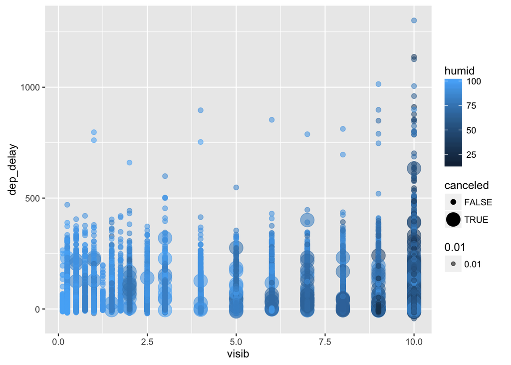

```r
fws<- ggplot(weather_join,
             aes(x=visib, y=dep_delay))

fws + geom_point(aes(alpha = 0.01, colour = humid, size = canceled))
```

Here we find that visbility increases the occurence of departure delays. There also seems to be a stronger correlation with low humidity and delays over high humidity and delays

## Indicating relationship between hour and departure delays, Max delays and Avg delays

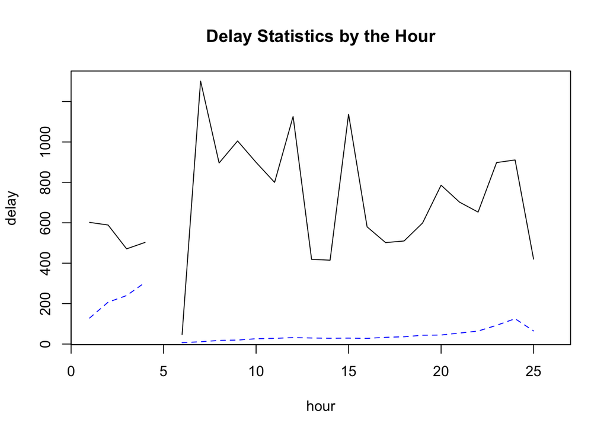

## Indicating relationship between days and departure delays, Max Delays

This plot only shows max delays for days throughout the given month. There is typically a spike in delays with in the 8 to 10 day mark, and then max delays typically die down as the month goes by.

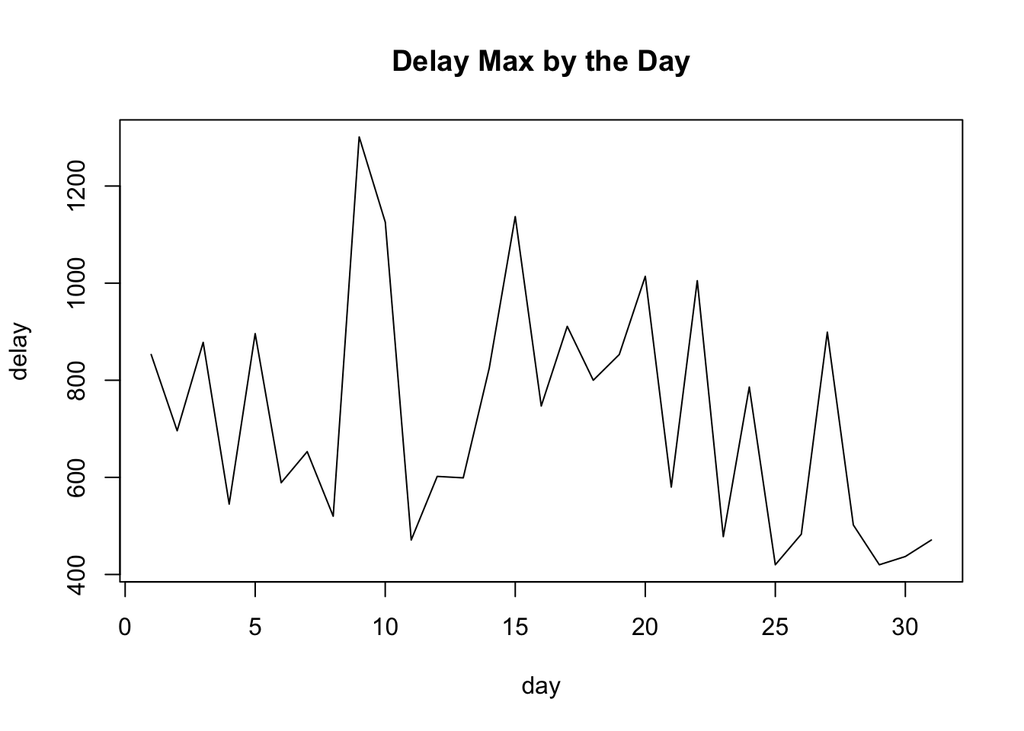

# Indicating relationship between days and delays, Avg Delays

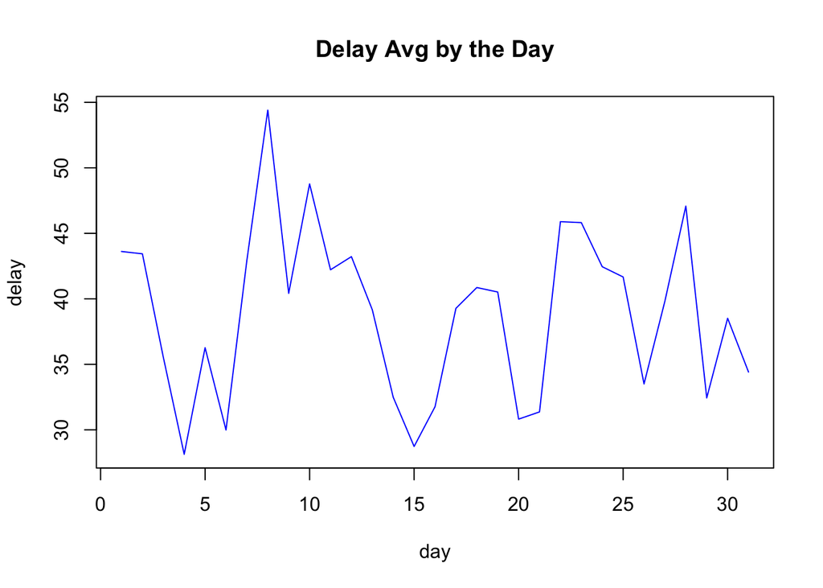

## Indicating relationship between Time of Year and delay, Max Delays

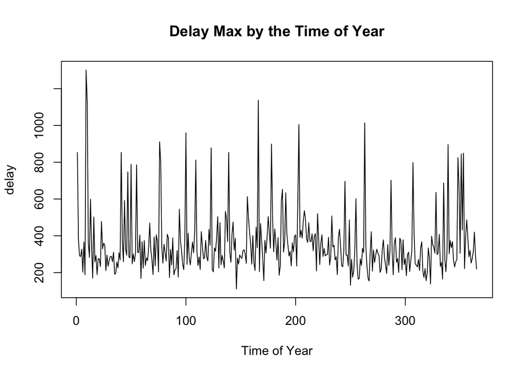

From this we can interpret that there is no significant trend in max delays during a given year.

# Indicating relationship between Time of Year and delay, Avg Delays

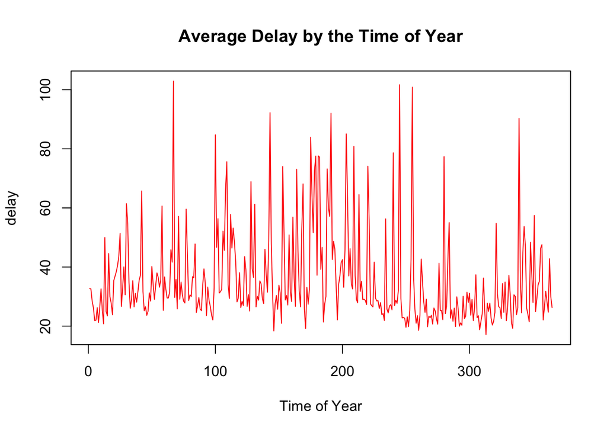

The same can be concluded for average delays

# Indicating Relationship between time and cancelation

```
##
## Call:
## glm(formula = flights$canceled ~ flights$hour, family = binomial(link = "probit"))
##
## Deviance Residuals:
##     Min       1Q   Median       3Q      Max
## -0.0768  -0.0592  -0.0508  -0.0434   3.9055
##
## Coefficients:
##               Estimate Std. Error z value Pr(>|z|)
## (Intercept)  -3.321295   0.046741 -71.057  < 2e-16 ***
## flights$hour  0.023636   0.003031   7.799 6.22e-15 ***
## ---
## Signif. codes:  0 '***' 0.001 '**' 0.01 '*' 0.05 '.' 0.1 ' ' 1
##
## (Dispersion parameter for binomial family taken to be 1)
##
##     Null deviance: 6938.5  on 328520  degrees of freedom
## Residual deviance: 6875.5  on 328519  degrees of freedom
##   (8255 observations deleted due to missingness)
## AIC: 6879.5
##
## Number of Fisher Scoring iterations: 9
```

```
##
## Call:
## glm(formula = flights$canceled ~ flights$day, family = binomial(link = "probit"))
##
## Deviance Residuals:
##     Min       1Q   Median       3Q      Max
## -0.2536  -0.2413  -0.2277  -0.2147   2.7874
##
## Coefficients:
##               Estimate Std. Error z value Pr(>|z|)
## (Intercept) -1.8511187  0.0090165 -205.30   <2e-16 ***
## flights$day -0.0061731  0.0005209  -11.85   <2e-16 ***
## ---
## Signif. codes:  0 '***' 0.001 '**' 0.01 '*' 0.05 '.' 0.1 ' ' 1
##
## (Dispersion parameter for binomial family taken to be 1)
##
##     Null deviance: 80884  on 336775  degrees of freedom
## Residual deviance: 80744  on 336774  degrees of freedom
## AIC: 80748
##
## Number of Fisher Scoring iterations: 6
```

```
##
## Call:
## glm(formula = flights$canceled ~ flights$month, family = binomial(link = "probit"))
##
## Deviance Residuals:
##     Min       1Q   Median       3Q      Max
## -0.2617  -0.2428  -0.2249  -0.2079   2.8109
##
## Coefficients:
##                Estimate Std. Error z value Pr(>|z|)
## (Intercept)   -1.807717   0.009405 -192.20   <2e-16 ***
## flights$month -0.021828   0.001341  -16.28   <2e-16 ***
## ---
## Signif. codes:  0 '***' 0.001 '**' 0.01 '*' 0.05 '.' 0.1 ' ' 1
##
## (Dispersion parameter for binomial family taken to be 1)
##
##     Null deviance: 80884  on 336775  degrees of freedom
## Residual deviance: 80616  on 336774  degrees of freedom
## AIC: 80620
##
## Number of Fisher Scoring iterations: 6
```

## Indicating relationship between destination and delays

```
## Source: local data frame [6 x 5]
##
##    dest max_delay avg_delay min_delay count
##   (chr)     (dbl)     (dbl)     (dbl) (int)
## 1   PSP        10  7.666667         6    19
## 2   EYW        40 15.285714         1    17
## 3   ANC        75 17.500000         2     8
## 4   HDN        46 20.777778         4    15
## 5   STT       366 22.739394         1   522
## 6   MTJ       122 23.090909         1    15
```

This give the 6 destinations with the least amount of delays.

# Indicating Relationship between destinations and cancellations

```
##
## Call:
## glm(formula = flights$canceled ~ flights$dest, family = binomial(link = "probit"))
##
## Deviance Residuals:
##     Min       1Q   Median       3Q      Max
## -0.5056  -0.2791  -0.2024  -0.1328   3.4398
##
## Coefficients:
##                   Estimate Std. Error z value Pr(>|z|)
## (Intercept)     -5.019e+00  1.475e+01  -0.340    0.734
## flights$destACK  2.365e-09  2.064e+01   0.000    1.000
## flights$destALB  3.353e+00  1.475e+01   0.227    0.820
## flights$destANC  2.272e-09  8.440e+01   0.000    1.000
## flights$destATL  2.962e+00  1.475e+01   0.201    0.841
## flights$destAUS  2.654e+00  1.475e+01   0.180    0.857
## flights$destAVL  3.309e+00  1.475e+01   0.224    0.822
## flights$destBDL  3.543e+00  1.475e+01   0.240    0.810
## flights$destBGR  3.327e+00  1.475e+01   0.226    0.822
## flights$destBHM  3.704e+00  1.475e+01   0.251    0.802
## flights$destBNA  3.247e+00  1.475e+01   0.220    0.826
## flights$destBOS  3.152e+00  1.475e+01   0.214    0.831
## flights$destBQN  2.546e+00  1.475e+01   0.173    0.863
## flights$destBTV  3.134e+00  1.475e+01   0.213    0.832
## flights$destBUF  3.032e+00  1.475e+01   0.206    0.837
## flights$destBUR  2.236e+00  1.475e+01   0.152    0.880
## flights$destBWI  3.395e+00  1.475e+01   0.230    0.818
## flights$destBZN  3.104e+00  1.475e+01   0.210    0.833
## flights$destCAE  3.654e+00  1.475e+01   0.248    0.804
## flights$destCAK  3.067e+00  1.475e+01   0.208    0.835
## flights$destCHO  3.820e+00  1.475e+01   0.259    0.796
## flights$destCHS  3.263e+00  1.475e+01   0.221    0.825
## flights$destCLE  3.245e+00  1.475e+01   0.220    0.826
## flights$destCLT  3.092e+00  1.475e+01   0.210    0.834
## flights$destCMH  3.429e+00  1.475e+01   0.232    0.816
## flights$destCRW  3.123e+00  1.475e+01   0.212    0.832
## flights$destCVG  3.410e+00  1.475e+01   0.231    0.817
## flights$destDAY  3.627e+00  1.475e+01   0.246    0.806
## flights$destDCA  3.462e+00  1.475e+01   0.235    0.814
## flights$destDEN  2.673e+00  1.475e+01   0.181    0.856
```

[output cut: 68 more lines]

```
## flights$destSTT  2.594e+00  1.475e+01   0.176    0.860
## flights$destSYR  3.131e+00  1.475e+01   0.212    0.832
## flights$destTPA  2.623e+00  1.475e+01   0.178    0.859
## flights$destTUL  3.440e+00  1.475e+01   0.233    0.816
## flights$destTVC  3.459e+00  1.475e+01   0.235    0.815
## flights$destTYS  3.640e+00  1.475e+01   0.247    0.805
## flights$destXNA  3.137e+00  1.475e+01   0.213    0.832
##
## (Dispersion parameter for binomial family taken to be 1)
##
##     Null deviance: 80884  on 336775  degrees of freedom
## Residual deviance: 76450  on 336671  degrees of freedom
## AIC: 76660
##
## Number of Fisher Scoring iterations: 13
```

Here I’ve run a regression of flights cancelled on destinations. All destinations appear to have a positive but very insignificant relationship with cancellations. We can interpret that destinations will not really determine whether there is a cancellation.

## Indicating relationship between plane characteristics and Delays

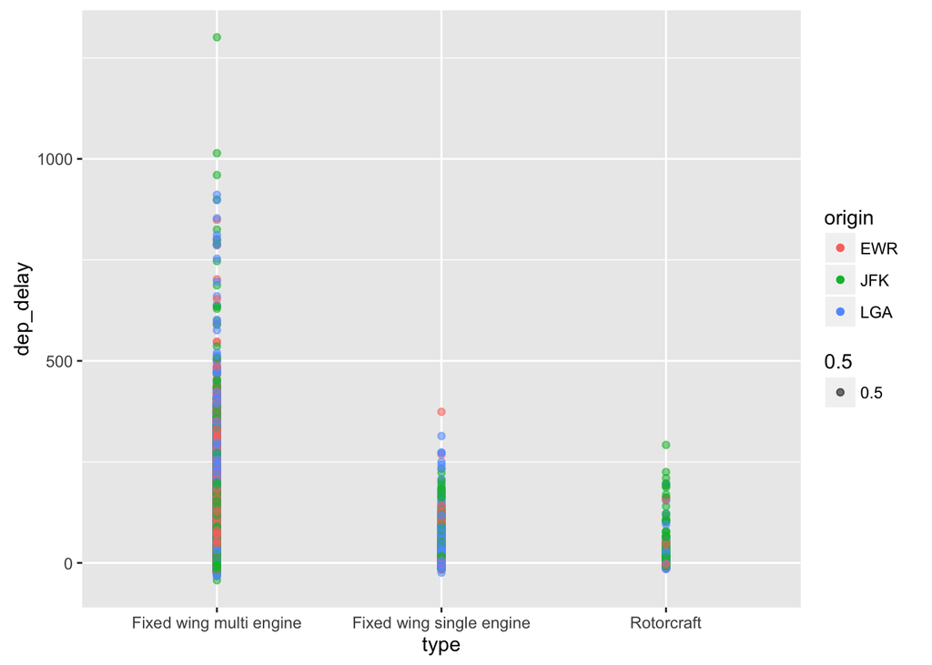

From this we can interpret that the Fixed wing multi engine leads to the most delays compared to the fixed wing singe engine and the Rotorcraft.

## Indicating relationship between plane characteristics and Cancellations

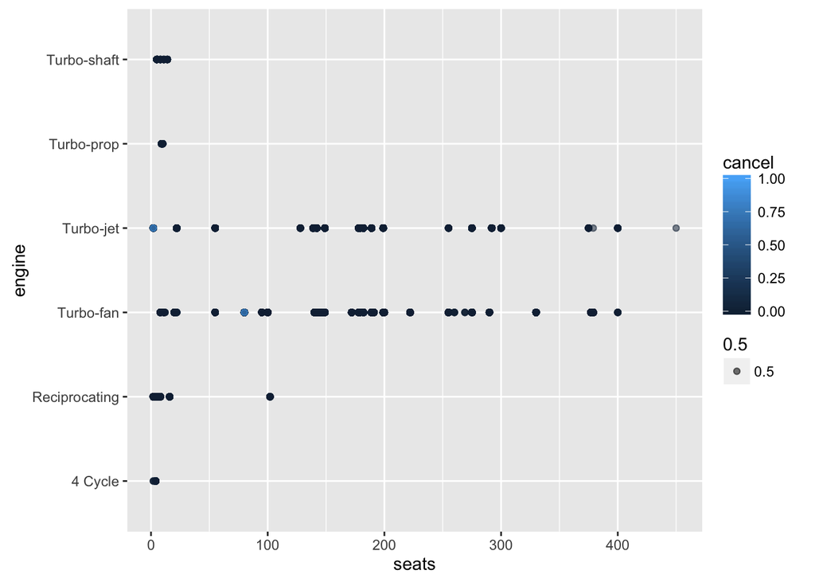

Blue dots are indicated by a flight being cancelled and black dots are indicated by flights not being cancelled. From here we can see that a flight is more likely to be cancelled if it has fewer seats and is a turbo-jet plane or a turbo-fan plane.